# Classifying each person’s response curve

### 4d. Layer 2 — measurement noise

This is the scatter of the dots around the participant’s own true curve. It is the only thing separating the simulation from a noiseless world.

```python
ptable([
 ("SLIDER_SD", f"{SLIDER_SD:g}",
  "Noise on a single slider response, in slider points, AT THE TOP OF A PEAK. Its ratio to PEAK_AMP is the master parameter of the whole document. Measurable for free from repeated pairs (§5c)."),
 ("NOISE_MODEL", f"{NOISE_MODEL}",
  "Whether response noise is the same size everywhere on the curve or shrinks where responses are small. See the figure below. 'proportional' is the default because 'constant' implies a participant who perceives almost no difference still scatters from 0 to 55 on the slider. §11.2 reports both: 'proportional' gives about 20% Type II, 'constant' about 38%, and the truth is bracketed by the two."),
 ("NOISE_FLOOR", f"{NOISE_FLOOR:g}",
  "Smallest response SD, in slider points. Used only by the 'floor' model."),
])
```

Table 5: Layer 2: measurement parameters.

| Parameter | Default | What it does |
| --- | --- | --- |
| SLIDER_SD | 12 | Noise on a single slider response, in slider points, AT THE TOP OF A PEAK. Its ratio to PEAK_AMP is the master parameter of the whole document. Measurable for free from repeated pairs (§5c). |
| NOISE_MODEL | proportional | Whether response noise is the same size everywhere on the curve or shrinks where responses are small. See the figure below. 'proportional' is the default because 'constant' implies a participant who p… |
| NOISE_FLOOR | 3 | Smallest response SD, in slider points. Used only by the 'floor' model. |

Figure 3: The shaded band is where a single response is likely to land. NOISE_MODEL decides whether that band is the same width all along the curve. All three give identical scatter at the top of a peak, so they differ only in how quiet a participant is where their responses are small. Under ‘constant’ a participant who perceives almost no difference still answers anywhere from 0 to 55, which is the implausible case; ‘proportional’ makes quiet participants quiet.

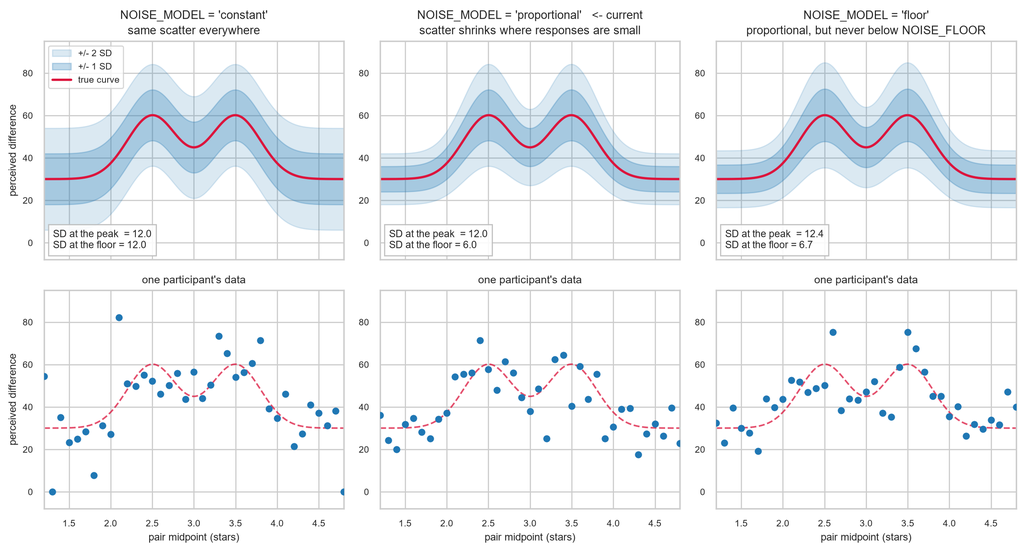

```python
_b2 = lambda x, m, w: np.exp(-0.5 * ((x - m) / w) ** 2)
_xs2 = np.linspace(MID_LO, MID_HI, 500)
_xd2 = np.linspace(MID_LO, MID_HI, 37)
_cv = lambda x: BASELINE + PEAK_AMP * (_b2(x, 2.5, PEAK_W) + _b2(x, 3.5, PEAK_W))
_top = BASELINE + PEAK_AMP
_r2 = np.random.default_rng(3)

def _sd_of(mu, model):
    mu = np.asarray(mu, float)
    if model == 'constant':
        return np.full_like(mu, SLIDER_SD)
    if model == 'proportional':
        return SLIDER_SD * mu / _top
    return np.sqrt(NOISE_FLOOR ** 2 + (SLIDER_SD * mu / _top) ** 2)

_MODELS = [('constant', 'same scatter everywhere'),
           ('proportional', 'scatter shrinks where responses are small'),
           ('floor', 'proportional, but never below NOISE_FLOOR')]

fig, ax = plt.subplots(2, 3, figsize=(12.5, 6.8), sharex=True)
for _c, (_mod, _sub) in enumerate(_MODELS):
    _mu, _mud = _cv(_xs2), _cv(_xd2)
    _s = _sd_of(_mu, _mod)
    a = ax[0, _c]
    a.fill_between(_xs2, _mu - 2 * _s, _mu + 2 * _s, color='#1f77b4', alpha=.16,
                   label='+/- 2 SD')
    a.fill_between(_xs2, _mu - _s, _mu + _s, color='#1f77b4', alpha=.28, label='+/- 1 SD')
    a.plot(_xs2, _mu, color='crimson', lw=2, label='true curve')
    _mark = "   <- current" if _mod == NOISE_MODEL else ""
    a.set_title(f"NOISE_MODEL = '{_mod}'{_mark}\n{_sub}", fontsize=10, linespacing=1.4)
    a.text(.03, .04,
           f"SD at the peak  = {_sd_of(np.array([_top]), _mod)[0]:.1f}\n"
           f"SD at the floor = {_sd_of(np.array([BASELINE]), _mod)[0]:.1f}",
           transform=a.transAxes, fontsize=8.5, va='bottom',
           bbox=dict(fc='white', ec='#bbb', alpha=.9))
    _y = np.clip(_mud + _r2.normal(0, 1, len(_xd2)) * _sd_of(_mud, _mod), 0, 100)
    b = ax[1, _c]
    b.plot(_xs2, _mu, color='crimson', ls='--', lw=1.4, alpha=.75)
    b.scatter(_xd2, _y, s=26, color='#1f77b4', zorder=3)
    b.set_title("one participant's data", fontsize=9.5)
    b.set_xlabel('pair midpoint (stars)', fontsize=9)
ax[0, 0].legend(fontsize=8, loc='upper left')
for a in ax.ravel():
    a.set_ylim(-8, 95)
    a.set_xlim(MID_LO, MID_HI)
    a.tick_params(labelsize=8)
ax[0, 0].set_ylabel('perceived difference', fontsize=9)
ax[1, 0].set_ylabel('perceived difference', fontsize=9)
plt.tight_layout()
plt.show()
```

**TipTip**

Repeat a few pairs at high-response midpoints and a few at low-response ones. The scatter within each repeated pair estimates the noise there directly, which settles both `SLIDER_SD` and `NOISE_MODEL` empirically instead of by assumption.